# Assignment |Reproducible Research Week 2

Juan M Sanchez

6/22/2020

### QUESTION 1| Code for reading in the dataset and/or processing the data.

I read and called data frame ‘act’.

```r
act<- read.csv(file='activity.csv', header = TRUE)
```

I checked data frame and ajust variable class:

```r
str(act)
```

```
## 'data.frame':    17568 obs. of  3 variables:
##  $ steps   : int  NA NA NA NA NA NA NA NA NA NA ...
##  $ date    : Factor w/ 61 levels "2012-10-01","2012-10-02",..: 1 1 1 1 1 1 1 1 1 1 ...
##  $ interval: int  0 5 10 15 20 25 30 35 40 45 ...
```

```r
act$steps <- as.numeric(as.character(act$steps))
act$interval <- as.numeric(as.character(act$interval))
act$date <- as.Date(act$date)
```

### QUESTION 2| Histogram of the total number of steps taken each day.

I used the following packages. “In this case I hide the result/message to avoid unnesasary data”:

```r
library(dplyr)
library(lubridate)
library(ggplot2)
```

First, I getting the information per day by groupon by “date” and summurize per “steps”.

```r
byday<- act %>% group_by(date) %>%
      summarize(steps=sum(steps))
```

Then, I plotted the graphic with ‘date’ variable on the X and ‘steps’ on the Y axis.

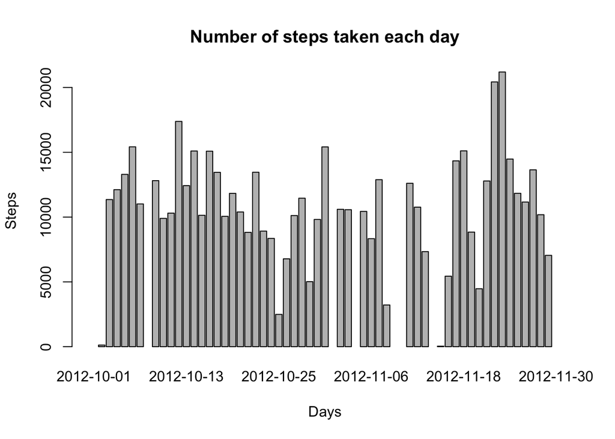

```r
barplot(byday$steps,names.arg=byday$date, xlab = "Days", ylab = "Steps", main = "Number of steps taken each day",)
```

### QUESTION 3| Mean and median number of steps taken each day.

Using the ‘byday’ data frame created on question 2, we can calculate mean and median of steps per day:

```r
mean(byday$steps,na.rm = TRUE)
```

```
## [1] 10766.19
```

```r
median(byday$steps,na.rm = TRUE)
```

```
## [1] 10765
```

### QUESTION 4 | Time series plot of the average number of steps taken.

First, I getting the average steps per day (mean) by groupon by “date” and summurize per “steps”:

```r
meanday<- act %>% group_by(date=floor_date(date, "day")) %>%
      summarise(steps=mean(steps))
```

I used ggplot2 to plot a time series graphic showing the mean steps per day:

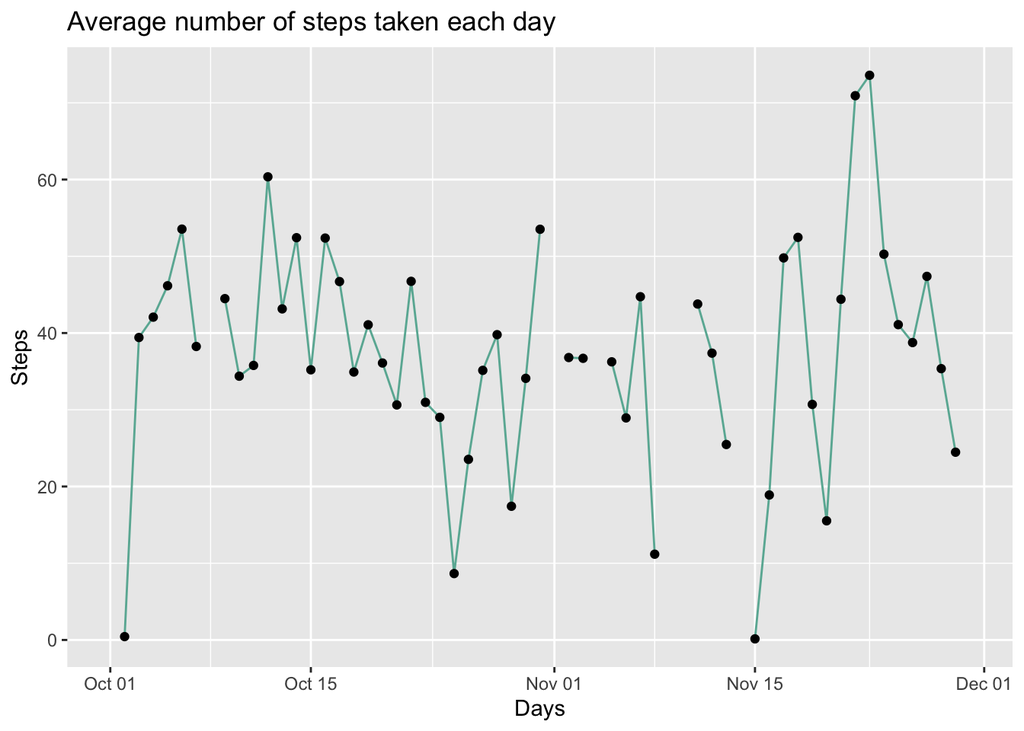

```r
tseries <- ggplot(meanday, aes(x=date, y=steps))+
   geom_line(color="#69b3a2")+
   geom_point()+
   xlab("Days")+
   ylab("Steps")+
   ggtitle("Average number of steps taken each day")
tseries
```

### QUESTION 5 | The 5-minute interval that, on average, contains the maximum number of steps.

Again, I used dplyr package to group steps by intervals and see the average number of steps of each one. Then I filter:

```r
inter<- act %>%
      filter(steps, interval) %>%
      group_by(interval) %>%
      summarise(steps=mean(steps)) %>%
      arrange(desc(steps))

inter[1,]
```

```
## # A tibble: 1 x 2
##   interval steps
##      <dbl> <dbl>
## 1      835  352.
```

### QUESTION 6 | Code to describe and show a strategy for imputing missing data.

First, launch “mice” Packages.

```r
library(mice)
```

Then, I run the mice function to impute values for missing numbers and check the 3 different imputation options to see is the imputaiton that makes more sence.

```r
impute <- mice(act[,1:3], m=3, seed = 123)
```

After that, I replaced the NA for the imputation values and compare the new data set act2, with the origina act.

```r
act2<- complete(impute,1)
summary(act2)
```

```
##      steps             date               interval
##  Min.   :  0.00   Min.   :2012-10-01   Min.   :   0.0
##  1st Qu.:  0.00   1st Qu.:2012-10-16   1st Qu.: 588.8
##  Median :  0.00   Median :2012-10-31   Median :1177.5
##  Mean   : 36.17   Mean   :2012-10-31   Mean   :1177.5
##  3rd Qu.: 10.00   3rd Qu.:2012-11-15   3rd Qu.:1766.2
##  Max.   :806.00   Max.   :2012-11-30   Max.   :2355.0
```

```r
summary(act)
```

```
##      steps             date               interval
##  Min.   :  0.00   Min.   :2012-10-01   Min.   :   0.0
##  1st Qu.:  0.00   1st Qu.:2012-10-16   1st Qu.: 588.8
##  Median :  0.00   Median :2012-10-31   Median :1177.5
##  Mean   : 37.38   Mean   :2012-10-31   Mean   :1177.5
##  3rd Qu.: 12.00   3rd Qu.:2012-11-15   3rd Qu.:1766.2
##  Max.   :806.00   Max.   :2012-11-30   Max.   :2355.0
##  NA's   :2304
```

Finally, we see above that act2 does not contain NA values. Below I plot a graph showing the imputation values in a different color.

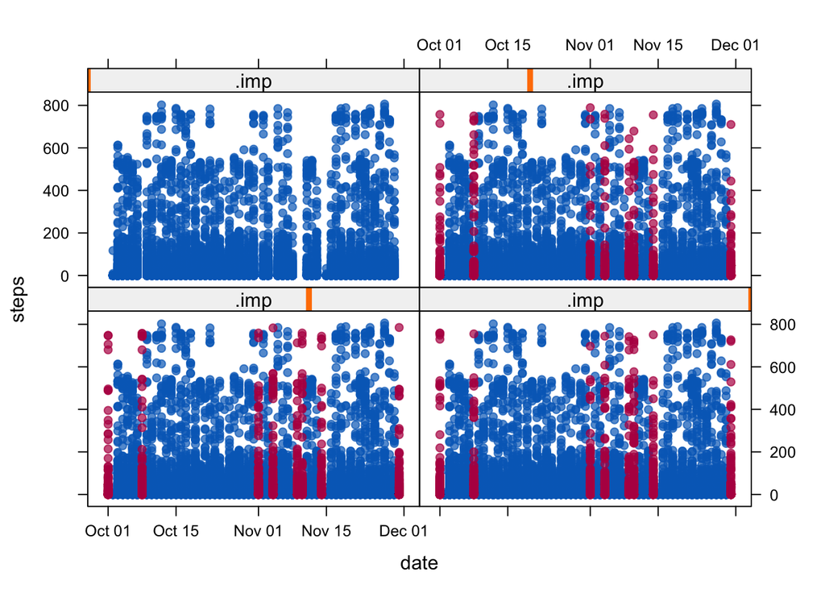

```r
xyplot(impute, steps~date | .imp, pch = 20, cex = 1.2)
```

### QUESTION 7 | Histogram of the total number of steps taken each day after missing values are imputed.

I created a new vector “baday2” with no mission values “taken the new data frame act2”. Then I grouped it by ‘date’ and sumaridez by ‘steps’.

```r
byday2 <- act2 %>% group_by(date) %>%
           summarize(steps=sum(steps))
```

Create a new graph with no NA values:

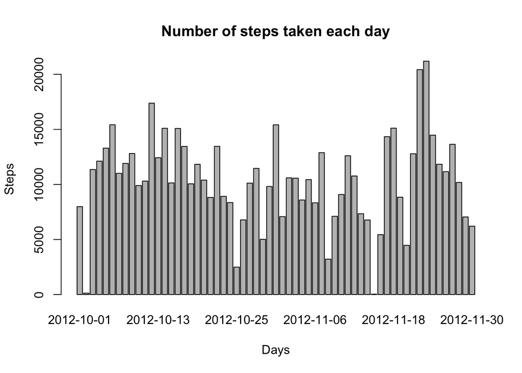

```r
barplot(byday2$steps,names.arg=byday2$date, xlab = "Days", ylab = "Steps", main = "Number of steps taken each day",)
```

### QUESTION 8 | Panel plot comparing the average number of steps taken per 5-minute interval across weekdays and weekends.

```r
act2$date <- as.Date(act2$date)
act2$steps <- as.numeric(as.character(act2$steps))
act2$interval <- as.numeric(as.character(act2$interval))
```

First, I created a new variable called wDay with the two levels (‘weekend’, ‘weekday’).

```r
weekdays1 <- c('Monday', 'Tuesday', 'Wednesday', 'Thursday', 'Friday')
act2$wDay <- factor((weekdays(act2$date) %in% weekdays1), levels=c(FALSE, TRUE), labels=c('weekend', 'weekday'))
```

Then, I group the data by ‘interval’ and summarise by ‘steps’.

```r
alldays<- act2 %>%
      group_by(interval, wDay) %>%
      summarise(steps=mean(steps))
```

Finally, I plotted a 2 graphic to compare ‘weekend’ and ‘weekday’ intervals.

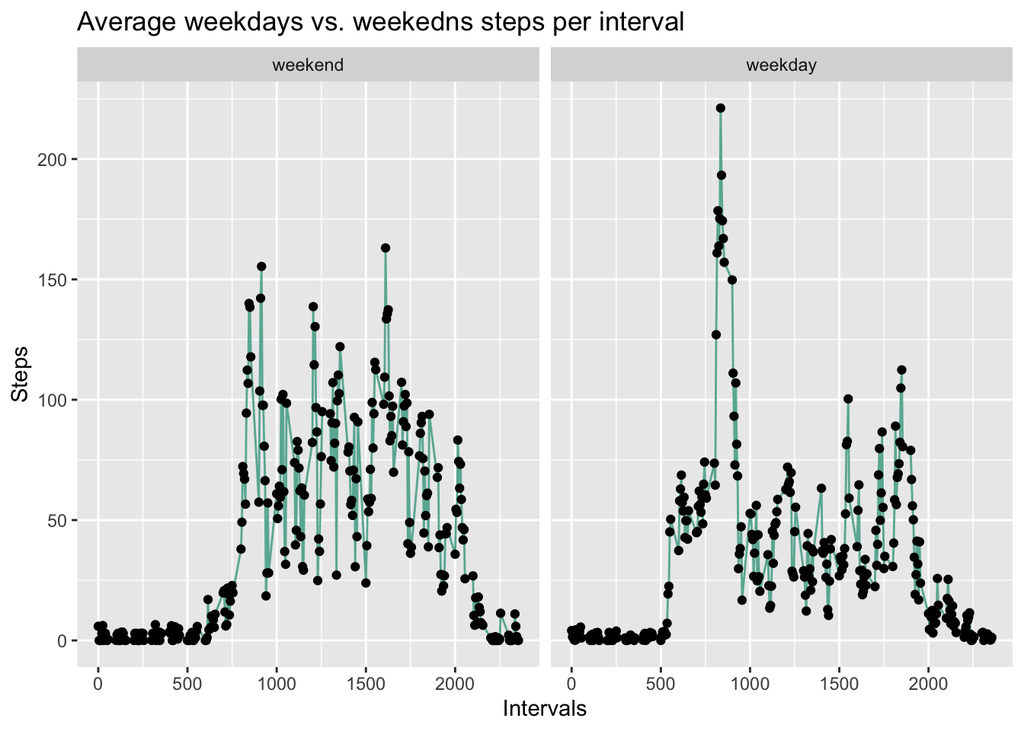

```r
wdayplot <- ggplot(alldays, aes(x=interval, y=steps)) +
   geom_line(color="#69b3a2") +
   geom_point()+
   facet_grid(.~wDay)+
   xlab("Intervals")+
   ylab("Steps")+
   ggtitle("Average weekdays vs. weekedns steps per interval")

wdayplot
```